# Flexible Damage Functions

Year 2099 · T<sub>mean</sub> across these regions: 1.96°C

| Region | Raw | Flex | Residual |
| --- | --- | --- | --- |
| CHN.15.167.1139 | 0.0158 | 0.0158 | -5.05e-5 |
| CHN.27.283.1960 | 0.265 | 0.265 | -6.45e-5 |
| KAZ.3.R5d865f160ce15c95 | 0.324 | 0.324 | 9.92e-5 |
| CHN.8.82.491 | 0.162 | 0.162 | -1.02e-4 |
| RUS.23.567.567 | 0.33 | 0.33 | 1.13e-4 |
| SOM.1.R472bf830dca32de3 | -5.16 | -16.1 | -10.9 |
| SOM.7.29 | -7.11 | -18 | -10.9 |
| SOM.2.6 | -6.53 | -16.6 | -10.1 |
| SOM.7.R33e9ff1321647aad | -6.12 | -16.2 | -10 |
| SOM.18.72 | -4.6 | -14.5 | -9.94 |

**rcp85**

**SSP2**

**high**

**Correlation:** 0.8962 | **RMSE:** 6.737329 | **Sign agreement:** 95.6%

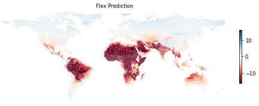

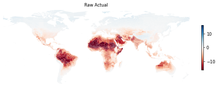

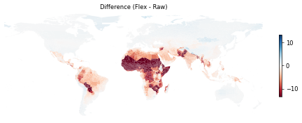

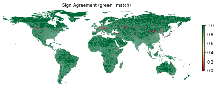

[interactive chart not shown]

Top 5 best predicted Top 5 worst predicted

Year 2099 · T<sub>mean</sub> across these regions: 4.20°C

| Region | Raw | Flex | Residual |
| --- | --- | --- | --- |
| MKD.5.Ra46220bda8aa7804 | -1.49 | -1.49 | -9.46e-6 |
| USA.36.2104 | -0.895 | -0.895 | 7.85e-5 |
| USA.42.2420 | -0.359 | -0.359 | 7.88e-5 |
| USA.35.2016 | -0.595 | -0.595 | -9.42e-5 |
| USA.36.2075 | -0.909 | -0.909 | -1.11e-4 |
| BFA.29 | -19.8 | -81.4 | -61.6 |
| BFA.36 | -18.6 | -78 | -59.4 |
| BFA.34 | -18.4 | -77.4 | -59 |
| BFA.23 | -17.9 | -75.6 | -57.7 |
| BFA.41 | -17.4 | -74.1 | -56.7 |

**low**

**Correlation:** 0.9588 | **RMSE:** 3.159588 | **Sign agreement:** 96.8%

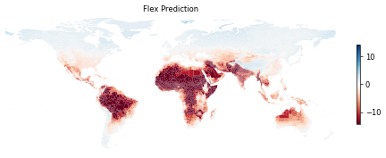

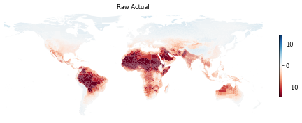

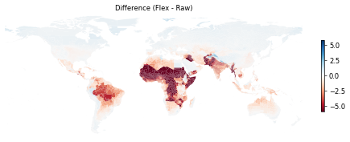

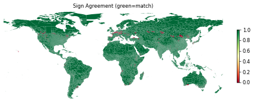

[interactive chart not shown]

Top 5 best predicted Top 5 worst predicted

Year 2099 · T<sub>mean</sub> across these regions: 4.20°C

| Region | Raw | Flex | Residual |
| --- | --- | --- | --- |
| USA.47.2859 | -0.877 | -0.877 | -5.54e-5 |
| AGO.2.10 | -1.21 | -1.21 | 9.74e-5 |
| MDG.3.11.47 | -0.55 | -0.55 | -1.36e-4 |
| KOR.1.14 | 0.0799 | 0.0797 | -1.85e-4 |
| USA.49.3044 | -0.394 | -0.394 | -2.76e-4 |
| SOM.7.29 | -17 | -65.2 | -48.2 |
| SOM.2.6 | -15.1 | -60.2 | -45.1 |
| SOM.1.R472bf830dca32de3 | -14.5 | -58.3 | -43.8 |
| SOM.7.R33e9ff1321647aad | -14.8 | -58.6 | -43.8 |
| SOM.2.5 | -13.3 | -55.5 | -42.2 |

**SSP3**

**high**

**Correlation:** 0.9352 | **RMSE:** 1.788975 | **Sign agreement:** 97.4%

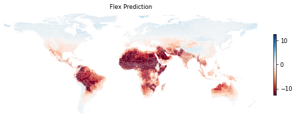

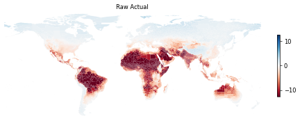

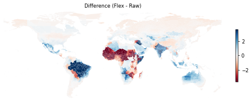

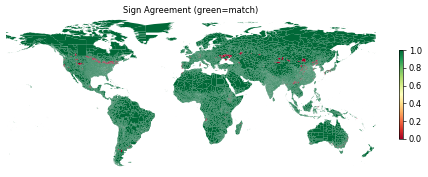

[interactive chart not shown]

Top 5 best predicted Top 5 worst predicted

Year 2099 · T<sub>mean</sub> across these regions: 4.20°C

| Region | Raw | Flex | Residual |
| --- | --- | --- | --- |
| IRN.30.262 | -1.68 | -1.68 | -1.85e-5 |
| CHN.10.91.596 | -1.34 | -1.34 | -3.38e-5 |
| TUR.40.440 | -0.159 | -0.159 | -6.60e-5 |
| CAN.11.198.3419 | 0.465 | 0.465 | 7.35e-5 |
| GTM.7.R3ac13e0d4823a7f4 | 0.676 | 0.676 | 8.54e-5 |
| GIN.4.15.R446f10eece8a6b24 | -14.9 | -31 | -16.1 |
| GIN.1.5.Rda4b5cf45d3e5b5e | -14.5 | -30.3 | -15.8 |
| GIN.1.5.33 | -14.1 | -29.7 | -15.6 |
| GIN.4.15.139 | -14.3 | -29.8 | -15.5 |
| BFA.29 | -24.4 | -39.4 | -15 |

**low**

**Correlation:** 0.9657 | **RMSE:** 2.136049 | **Sign agreement:** 98.5%

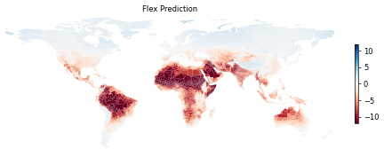

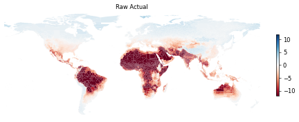

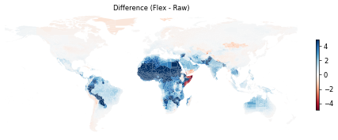

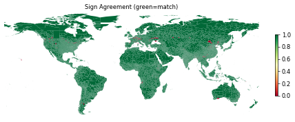

[interactive chart not shown]

Top 5 best predicted Top 5 worst predicted

Year 2099 · T<sub>mean</sub> across these regions: 4.20°C

| Region | Raw | Flex | Residual |
| --- | --- | --- | --- |
| KAZ.13.162 | -0.267 | -0.267 | -2.55e-5 |
| JPN.33.1361 | -0.487 | -0.487 | -3.84e-5 |
| AFG.19.Rb70c80870c4e3972 | -6.92 | -6.92 | 3.93e-5 |
| MEX.13.Raadeeb5275e655ab | -0.0689 | -0.0689 | 4.28e-5 |
| USA.35.2045 | -0.0883 | -0.0883 | -5.48e-5 |
| TCD.1.3 | -28.2 | -15.2 | 13 |
| TCD.1.1 | -28 | -15.1 | 12.9 |
| TCD.14.42 | -26.9 | -14.4 | 12.6 |
| TCD.1.2 | -27.1 | -14.5 | 12.6 |
| TCD.18.51 | -26 | -13.5 | 12.5 |

**SSP4**

**high**

**Correlation:** 0.9333 | **RMSE:** 2.017672 | **Sign agreement:** 95.2%

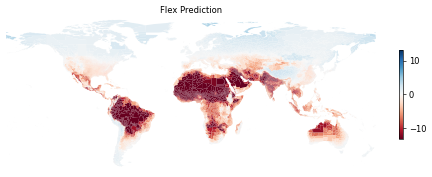

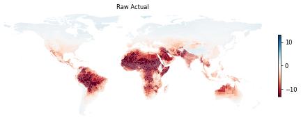

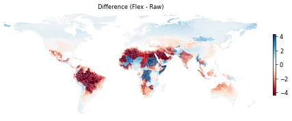

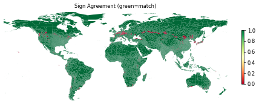

[interactive chart not shown]

Top 5 best predicted Top 5 worst predicted

Year 2099 · T<sub>mean</sub> across these regions: 4.20°C

| Region | Raw | Flex | Residual |
| --- | --- | --- | --- |
| VEN.7.67 | -1.47 | -1.47 | 6.17e-5 |
| AUS.4.278 | -0.795 | -0.796 | -1.24e-4 |
| MEX.30.1514 | -0.542 | -0.542 | -2.52e-4 |
| AGO.3.18 | -2.09 | -2.09 | 2.53e-4 |
| CHN.31.326.2271 | -0.371 | -0.371 | 2.95e-4 |
| BOL.8.84.286 | -16.7 | -32 | -15.3 |
| BOL.3.27.79 | -17.6 | -32.7 | -15.1 |
| BOL.3.27.80 | -17.2 | -32.3 | -15 |
| BOL.3.30.88 | -16.9 | -31.6 | -14.8 |
| BOL.3.27.81 | -16.6 | -31.4 | -14.8 |

**low**

**Correlation:** 0.9740 | **RMSE:** 1.477923 | **Sign agreement:** 97.4%

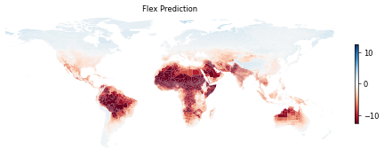

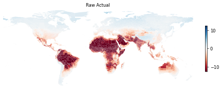

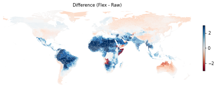

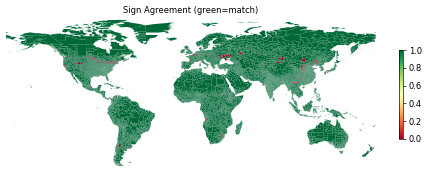

[interactive chart not shown]

Top 5 best predicted Top 5 worst predicted

Year 2099 · T<sub>mean</sub> across these regions: 4.20°C

| Region | Raw | Flex | Residual |
| --- | --- | --- | --- |
| CAN.13.293.5577 | 0.609 | 0.609 | -7.73e-6 |
| AUS.10.1102 | 0.327 | 0.327 | 3.23e-5 |
| KAZ.1.2 | -0.441 | -0.441 | -3.69e-5 |
| CAN.6.97.R99cfadeab175fd9c | 0.842 | 0.842 | 4.10e-5 |
| CAN.13.293.5561 | 0.799 | 0.799 | 4.75e-5 |
| SOM.7.29 | -20.2 | -38.6 | -18.4 |
| SOM.1.R472bf830dca32de3 | -16.9 | -34.6 | -17.7 |
| SOM.2.6 | -18.3 | -35.7 | -17.4 |
| SOM.7.R33e9ff1321647aad | -17.9 | -34.7 | -16.8 |
| SOM.2.5 | -16.2 | -32.9 | -16.7 |

## 10.1 Scenario Summary

Table 7: Fit statistics across all 12 scenarios

| RCP | SSP | Model | N | Corr | RMSE | Sign% |
| --- | --- | --- | --- | --- | --- | --- |
| rcp45 | SSP2 | high | 24,326 | 0.8596 | 3.17308 | 96.6% |
| rcp45 | SSP2 | low | 24,326 | 0.9341 | 1.75725 | 94.8% |
| rcp45 | SSP3 | high | 24,326 | 0.9076 | 0.969157 | 97.1% |
| rcp45 | SSP3 | low | 24,326 | 0.9674 | 0.435858 | 97.5% |
| rcp45 | SSP4 | high | 24,326 | 0.9441 | 0.954353 | 96.5% |
| rcp45 | SSP4 | low | 24,326 | 0.9512 | 0.588722 | 96.4% |
| rcp85 | SSP2 | high | 24,326 | 0.8962 | 6.73733 | 95.6% |
| rcp85 | SSP2 | low | 24,326 | 0.9588 | 3.15959 | 96.8% |
| rcp85 | SSP3 | high | 24,326 | 0.9352 | 1.78897 | 97.4% |
| rcp85 | SSP3 | low | 24,326 | 0.9657 | 2.13605 | 98.5% |
| rcp85 | SSP4 | high | 24,326 | 0.9333 | 2.01767 | 95.2% |
| rcp85 | SSP4 | low | 24,326 | 0.974 | 1.47792 | 97.4% |

# 11 Data Reference

## 11.1 File Locations

| Item | Path |
| --- | --- |
| Regional CSV | `/project/cil/gcp/flex_damage_funcs/parameters/labor__combined__regional_parameters.csv` |
| Global JSON | `/project/cil/gcp/flex_damage_funcs/parameters/labor__combined__global_results.json` |
| Metadata JSON | `/project/cil/gcp/flex_damage_funcs/parameters/labor__combined__metadata.json` |

## 11.2 Column Definitions

| Column | Description |
| --- | --- |
| `region` | Region identifier (hierarchical code, first 3 chars = country ISO3) |
| `gamma` | Income elasticity quantile value |
| `alpha` | Linear temperature coefficient |
| `beta` | Quadratic temperature coefficient |
| `sigma11` | Var(alpha) |
| `sigma12` | Cov(alpha, beta) |
| `sigma22` | Var(beta) |
| `rho` | Correlation with global residual process |
| `zeta` | Temperature-dependent heteroskedasticity |
| `eta` | Residual standard deviation |
| `rsqr1` | R-squared of polynomial fit |
| `rsqr2` | R-squared of error model |

*Report generated with FlexDamage v1.0.0*